# Manual Crack Classification

# 1. Shuffle all Images into Train and Test Folder

```python
from PIL import Image
from IPython.display import display
from sklearn.model_selection import train_test_split
from matplotlib import pyplot as plt
import pylab, random, os, math, sklearn
import numpy as np
import tensorflow as tf

# To cancel scientific notation
np.set_printoptions(suppress=True)

%matplotlib inline
# %matplotlib tk
%config InlineBackend.figure_format = 'retina'

# To set plotting style
plt.style.use("classic")
plt.style.use("bmh")
plt.style.use("seaborn-whitegrid")

# To hide warnings
import warnings
warnings.filterwarnings("ignore")
```

The number of labeled image is only 120.

```python
! find /Users/ray/Desktop/crack-images/LCMS-Range-Labeled/annotations -type f -regex ".*xml" | wc -l
```

```
     120
```

It's far from enough for us to train the model using nuerual network. We still need to label the test data manuallly. There are in total 13745 images in the test folder.

```python
! find /Users/ray/Desktop/crack-images/LCMS-Range -type f -regex ".*JPG" | wc -l
```

```
   13745
```

Ideally we need at least 10000 samples to train our model. Since each original image actually contains three 410 $\times$ 410 small images by cropping and splitting, we can use 4000 images to generate 12000 samples to train our model.

We noticed that the labeled train data is essentially a subset of the unlabeled data, for example:

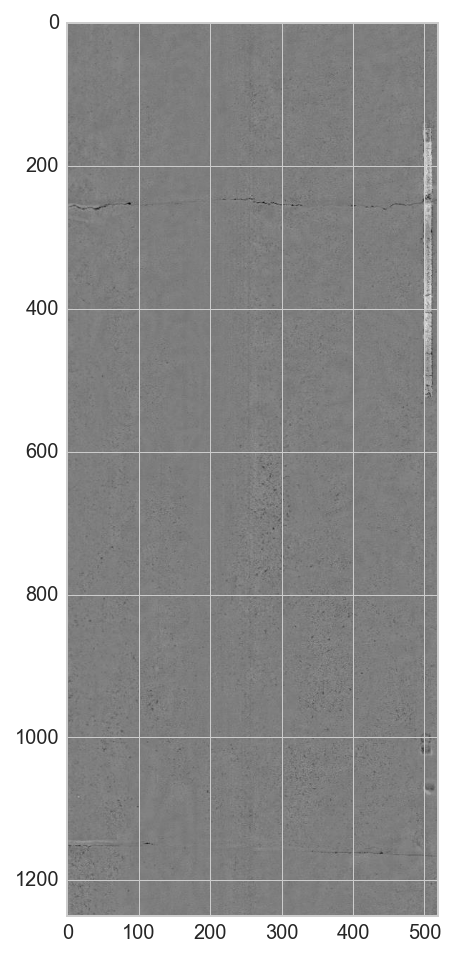

```python
from tensorflow.keras.preprocessing.image import load_img
from tensorflow.keras.preprocessing.image import img_to_array

path = "/Users/ray/Desktop/crack-images/LCMS-Range-Labeled/images/000000670000.JPG"
img = img_to_array(load_img(path)).astype(int)
plt.figure(figsize=(4,8))
plt.imshow(img)
plt.show()
```

And we search the image with the same name in the test folder:

```python
! find /Users/ray/Desktop/crack-images/LCMS-Range -name 000000670000.JPG
```

```
/Users/ray/Desktop/crack-images/LCMS-Range/172M0OYG790/000000000000/000000670000.JPG
/Users/ray/Desktop/crack-images/LCMS-Range/172J0HYQF90/000000000000/000000670000.JPG
/Users/ray/Desktop/crack-images/LCMS-Range/172H11Y2D90/000000000000/000000670000.JPG
/Users/ray/Desktop/crack-images/LCMS-Range/172I0QYQ190/000000000000/000000670000.JPG
/Users/ray/Desktop/crack-images/LCMS-Range/172H0YY1Z90/000000000000/000000670000.JPG
```

We find that `LCMS-Range-Labeled/images/000000670000.JPG` and `LCMS-Range/172J0HYQF90/000000000000/000000670000.JPG` are essentailly the same.

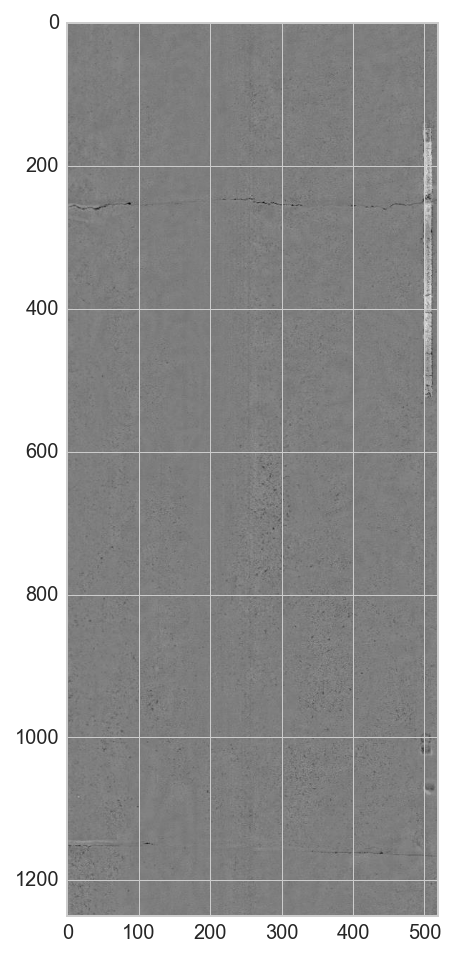

```python
path = "/Users/ray/Desktop/crack-images/LCMS-Range/172J0HYQF90/000000000000/000000670000.JPG"
img = img_to_array(load_img(path)).astype(int)
plt.figure(figsize=(4,8))
plt.imshow(img)
plt.show()
```

Therefore we cannot use the lebeled data as our train-set to avoid repeatness.

```python
import shutil

PATH = "/Users/ray/Desktop/crack-images/LCMS-Range-Shuffled"
TRAIN_PATH = os.path.join(PATH, "train")
TEST_PATH = os.path.join(PATH, "test")
# try:
#     os.mkdir(PATH)
#     os.mkdir(TRAIN_PATH)
#     os.mkdir(TEST_PATH)
# except:
#     shutil.rmtree(PATH)
#     os.mkdir(PATH)
#     os.mkdir(TRAIN_PATH)
#     os.mkdir(TEST_PATH)
```

Copy all unlabeled images to folder `LCMS-Range-Shuffled` and rename them.

```python
ORIGINAL_PATH = "/Users/ray/Desktop/crack-images/LCMS-Range"
TRAIN_NUM = 4000
count = 0
# for root, subdirs, files in os.walk(ORIGINAL_PATH):
#     for filename in files:
#         if filename.endswith("JPG"):
#             count += 1
#             new_filename = str(count).zfill(5) + ".JPG"
#             if count <= TRAIN_NUM:
#                 shutil.copyfile(os.path.join(root, filename), os.path.join(TRAIN_PATH, new_filename))
#             else:
#                 shutil.copyfile(os.path.join(root, filename), os.path.join(TEST_PATH, new_filename))
```

To see all the images are copied to the new folder and renamed.

```python
! find /Users/ray/Desktop/crack-images/LCMS-Range-Shuffled/train -type f -regex ".*JPG" | wc -l
```

```
    4000
```

```python
! find /Users/ray/Desktop/crack-images/LCMS-Range-Shuffled/test -type f -regex ".*JPG" | wc -l
```

```
    9745
```

# 2. Manually Label the Train Images

Use `dearpygui` to build a simple operation panel for easier manual classification.

Click [here](https://github.com/Ramray753/UOM-MAST90106-Group-26) for GitHub Link.